# GRUK_veg_analyse_2021_2025

Joachim Töpper

2025-10-31

# upload data sets

GRUK data: GRUK.species contains the species data, GRUK.variable contains site data, GRUK2021.condition contains a field-based condition assessment from the 2021 season.

Plant indicators from Tyler et al. (2021) and Grime (1974) are saved as ind.Tyler and ind.Grime.

Generalized species lists (reference communities): natopen_NiN_ref contains the reference species lists, natopen_NiN_ref_spInfo contains additional taxonomic information for each species.

# Data handling

- Checking for errors
- Checking species nomenclature in the different species lists to make species and indicator data possible to merge
- Merging indicator data with monitoring data and indicator data with reference data (not shown here, but documented in the code)

leaving us with the monitoring data including plant indicators (GRUK.species.ind) and the reference data including plant indicators (NiN.natopen.cov)

```r
head(GRUK.species.ind)
```

```
##                         ParentGlobalID               Species art_dekning Year
## 1 001360f4-82ba-4003-afce-b33c61c065d2       Acinos arvensis         2.0 2024
## 2 001360f4-82ba-4003-afce-b33c61c065d2         Poa compressa         0.1 2024
## 3 001360f4-82ba-4003-afce-b33c61c065d2            Sedum acre         1.0 2024
## 4 001360f4-82ba-4003-afce-b33c61c065d2  Artemisia campestris         1.0 2024
## 5 001360f4-82ba-4003-afce-b33c61c065d2         Festuca ovina         5.0 2024
## 6 001360f4-82ba-4003-afce-b33c61c065d2 Pilosella officinarum        14.0 2024
##   PolygonID  RuteID        CC        SS        RR Light Nitrogen
## 1     101-2 101-2-2        NA        NA        NA    NA       NA
## 2     101-2 101-2-2 0.1666667 0.4166667 0.4166667     7        4
## 3     101-2 101-2-2 0.0000000 0.7500000 0.2500000     7        4
## 4     101-2 101-2-2        NA        NA        NA     7        4
## 5     101-2 101-2-2 0.0000000 1.0000000 0.0000000     5        3
## 6     101-2 101-2-2 0.1666667 0.6666667 0.1666667     7        3
##   Soil_disturbance RuteID_loknr Dekning_karplanter_feltsjikt Dekning_moser
```

[output cut: 48 more lines]

```r
head(NiN.natopen.cov)
```

```
##                     sp T1_toerkeutsatte_berg T1-C-11 T1-C-12 T1_fosseberg
## 1 Achillea millefolium                    NA      NA      NA           NA
## 2    Achillea ptarmica                    NA      NA      NA           NA
## 3  Aconitum lycoctonum                    NA      NA      NA           NA
## 4       Actaea spicata                    NA      NA      NA           NA
## 5  Agrimonia eupatoria                    NA      NA      NA           NA
## 6    Agrimonia procera                    NA      NA      NA           NA
##   T2-C-1 T2-C-2 T2-C-3 T2-C-4 T2-C-5 T2-C-6 T2-C-7 T2-C-8 T2-C-7_BN T2-C-8_BN
## 1     NA     NA     NA     NA     NA     NA     NA     NA        NA        NA
## 2     NA     NA     NA     NA     NA     NA     NA     NA        NA        NA
## 3     NA     NA     NA     NA     NA     NA     NA     NA        NA        NA
## 4     NA     NA     NA     NA     NA     NA     NA     NA        NA        NA
## 5     NA     NA     NA     NA  0.375     NA  0.375     NA   0.03125   0.03125
## 6     NA     NA     NA     NA     NA     NA     NA     NA   0.03125   0.03125
##   T8-C-1 T8-C-2 T8-C-3 T11-C-1 T11-C-2 T12-C-1 T12-C-2 T13-C-1 T13-C-2 T13-C-3
```

[output cut: 62 more lines]

##### bootstrap function for frequency abundance

- function to calculate community weighted means of selected indicator values (ind)
- for species lists (sp) with given abundances in percent (or on a scale from 0 to 1) in one or more ‘sites’ (abun)
- with a given number of iterations (iter),
- with species given a certain minimum abundance occurring in all bootstraps (obl), and
- with a given re-sampling ratio of the original species list (rat)
- in every bootstrap iteration the abundance of the sampled species can be randomly changed by a limited amount if wished by introducing a re-sampling of abundance values from adjacent abundance steps with a certain probability (var.abun)

Running the bootstraps

```r
colnames(NiN.natopen)
# 1st column is the species
# 6th-71st column is the abundances of sp in different ecosystem types
# 74th-79th column is the indicator values of the respective species
# we choose 1000 iterations
# species with abundance 1 (i.e. a max of 100%, must be included in each sample)
# each sample re-samples 1/3 of the number of species
# the abundance of the re-sampled species may vary (see bootstrap function for details)
natopen.ref.cov <- indBoot.freq(sp=NiN.natopen.cov[,1],abun=NiN.natopen.cov[,6:71],ind=NiN.natopen.cov[,74:79],iter=1000,obl=1,rat=1/3,var.abun=T)

### fixing NaN's
for (i in 1:length(natopen.ref.cov) ) {
  for (j in 1:ncol(natopen.ref.cov[[i]]) ) {
    v <- natopen.ref.cov[[i]][,j]
    v[is.nan(v)] <- NA
    natopen.ref.cov[[i]][,j] <- v
  }
}
```

```r
head(natopen.ref.cov[[1]])
```

```
##      T2-C-1    T2-C-2    T2-C-3    T2-C-4    T2-C-5     T2-C-6    T2-C-7
## 1 0.2145390 0.2420403 0.1565114 0.1230769 0.2665436 0.14294187 0.2473216
## 2 0.3000000 0.1833333 0.1846847 0.1108156 0.2692308 0.15470297 0.3381174
## 3 0.2167449 0.0800000 0.3020833 0.0952381 0.2625831 0.03603604 0.3394756
## 4 0.3377193 0.1500000 0.1716687 0.1500000 0.3338446 0.08666667 0.3217825
## 5 0.3020833 0.1862745 0.2150860 0.1360544 0.3447429 0.22619048 0.2820722
## 6 0.2638889 0.2333333 0.2333333 0.1322464 0.2147766 0.05427842 0.1807244
##      T2-C-8 T2-C-7_BN T2-C-8_BN    T8-C-1 T8-C-2     T8-C-3 T11-C-1 T11-C-2
## 1 0.2751487 0.1888974 0.2437604 0.2439024     NA 0.12820513      NA      NA
## 2 0.2621895 0.2257394 0.1543064 0.2222222     NA 0.24796748      NA      NA
## 3 0.2091195 0.3598087 0.1719098 0.3691136     NA 0.10256410      NA      NA
## 4 0.2370130 0.2501856 0.1005212 0.1742424     NA 0.11111111      NA      NA
## 5 0.2887679 0.2605148 0.2265134 0.3219036     NA 0.15000000      NA      NA
## 6 0.2672673 0.1903744 0.1197554 0.2573099     NA 0.08843537      NA      NA
##     T12-C-1   T12-C-2 T13-C-1 T13-C-2 T13-C-3 T13-C-4   T13-C-5   T13-C-6
```

[output cut: 55 more lines]

This results in an R-list with a slot for every selected indicator, and in every slot there’s a data frame with as many columns as there are NiN species lists and as many rows as there were iterations in the bootstrap. Next, we need to derive scaling values from these bootstrap-lists (the columns) for every mapping unit in NiN. Here, we define things in the following way:

- Median = reference values
- 0.025 and 0.975 quantiles = lower and upper limit values
- min and max of the respective indicator’s scale = min/max values

```
##  [1] "T2-C-1"             "T2-C-2"             "T2-C-3"
##  [4] "T2-C-4"             "T2-C-5"             "T2-C-6"
##  [7] "T2-C-7"             "T2-C-8"             "T2-C-7_BN"
## [10] "T2-C-8_BN"          "T8-C-1"             "T8-C-2"
## [13] "T8-C-3"             "T11-C-1"            "T11-C-2"
## [16] "T12-C-1"            "T12-C-2"            "T13-C-1"
## [19] "T13-C-2"            "T13-C-3"            "T13-C-4"
## [22] "T13-C-5"            "T13-C-6"            "T13-C-7"
## [25] "T13-C-8"            "T13-C-9"            "T13-C-10"
## [28] "T13-C-11"           "T13-C-12"           "T13-C-13"
## [31] "T13-C-14"           "T13-C-15"           "T15"
## [34] "T15-Bratli21"       "T16-C-1"            "T16-C-2"
## [37] "T16-C-3"            "T16-C-4"            "T16-C-5"
## [40] "T16-C-6"            "T16-C-7"            "T18-C-1"
## [43] "T18-C-2"            "T18-C-3"            "T18-C-4"
## [46] "T21-C-1"            "T21-C-2"            "T21-C-3"
## [49] "T21-C-4"            "T21-7"              "T24-C-1_samlet"
## [52] "T24-C-2_samlet"     "T24-C-1_Moere"      "T24-C-1_Troendelag"
## [55] "T24-C-1_Troms"      "T24-C-1_Finnmark"   "T24-C-2_Moere"
## [58] "T24-C-2_Troendelag" "T24-C-2_Troms"      "T24-C-2_Finnmark"
## [61] "T29-C-1"            "T29-C-2"            "T29-C-3"
## [64] "T29-C-4"            "T29-C-5"            "T29-C-6"
```

```
##  [1] "T2-C-1"             "T2-C-2"             "T2-C-3"
##  [4] "T2-C-4"             "T2-C-5"             "T2-C-6"
##  [7] "T2-C-7"             "T2-C-8"             "T2-C-7_BN"
## [10] "T2-C-8_BN"          "T8-C-1"             "T8-C-2"
## [13] "T8-C-3"             "T11-C-1"            "T11-C-2"
## [16] "T12-C-1"            "T12-C-2"            "T13-C-1"
## [19] "T13-C-2"            "T13-C-3"            "T13-C-4"
## [22] "T13-C-5"            "T13-C-6"            "T13-C-7"
## [25] "T13-C-8"            "T13-C-9"            "T13-C-10"
## [28] "T13-C-11"           "T13-C-12"           "T13-C-13"
## [31] "T13-C-14"           "T13-C-15"           "T15"
## [34] "T15-Bratli21"       "T16-C-1"            "T16-C-2"
## [37] "T16-C-3"            "T16-C-4"            "T16-C-5"
## [40] "T16-C-6"            "T16-C-7"            "T18-C-1"
## [43] "T18-C-2"            "T18-C-3"            "T18-C-4"
## [46] "T21-C-1"            "T21-C-2"            "T21-C-3"
## [49] "T21-C-4"            "T21-7"              "T24-C-1_samlet"
## [52] "T24-C-2_samlet"     "T24-C-1_Moere"      "T24-C-1_Troendelag"
## [55] "T24-C-1_Troms"      "T24-C-1_Finnmark"   "T24-C-2_Moere"
## [58] "T24-C-2_Troendelag" "T24-C-2_Troms"      "T24-C-2_Finnmark"
## [61] "T29-C-1"            "T29-C-2"            "T29-C-3"
## [64] "T29-C-4"            "T29-C-5"            "T29-C-6"
```

```
##            V1         V2        V3          V4         V5        V6          V7
## 1  0.08720238 0.21872555 0.3853476 0.500000000 0.66915423 0.7423207 0.005865509
## 2  0.06666667 0.19841270 0.2800000 0.433284314 0.66666667 0.7833578 0.000000000
## 3  0.04000874 0.17389674 0.3768117 0.330085785 0.56021292 0.7852941 0.027769644
## 4  0.02849050 0.12157981 0.1959119 0.313876812 0.56307478 0.7672169 0.125237474
## 5  0.10653522 0.20833333 0.3330354 0.360629117 0.51651091 0.6814669 0.111343149
## 6  0.01331855 0.09462017 0.2539388 0.413919457 0.57812500 0.7601378 0.098987481
## 7  0.16355646 0.25828457 0.3689686 0.435462067 0.55250307 0.6627219 0.097762167
## 8  0.17006247 0.24058202 0.3256514 0.485129079 0.58220422 0.6901331 0.077630270
## 9  0.10685936 0.21440518 0.3476134 0.467295577 0.57512220 0.7397768 0.085402014
## 10 0.06413888 0.17452301 0.3335134 0.469214720 0.61855602 0.8002931 0.077959080
## 11 0.09522783 0.22200855 0.3741677 0.149935897 0.33492193 0.5380860 0.257080026
## 12         NA         NA        NA          NA         NA        NA          NA
## 13 0.02468383 0.15151515 0.2828283 0.346085858 0.57575758 0.8082121 0.132544192
## 14         NA         NA        NA          NA         NA        NA          NA
```

[output cut: 186 more lines]

```
## [1] 66 19
```

```
##      V1   V2   V3   V4   V5   V6   V7   V8   V9  V10  V11  V12  V13  V14  V15
## 1  0.09 0.22 0.39 0.50 0.67 0.74 0.01 0.11 0.30 2.84 4.47 5.43 1.65 2.62 3.76
## 2  0.07 0.20 0.28 0.43 0.67 0.78 0.00 0.16 0.41 3.29 4.80 6.29 1.29 2.29 3.44
## 3  0.04 0.17 0.38 0.33 0.56 0.79 0.03 0.24 0.56 3.36 4.83 6.18 1.81 3.20 4.48
## 4  0.03 0.12 0.20 0.31 0.56 0.77 0.13 0.32 0.53 4.52 5.72 6.72 1.85 2.98 4.35
## 5  0.11 0.21 0.33 0.36 0.52 0.68 0.11 0.26 0.45 4.50 5.28 6.01 2.56 3.52 4.85
## 6  0.01 0.09 0.25 0.41 0.58 0.76 0.10 0.30 0.51 4.72 5.74 6.66 2.48 3.21 4.17
## 7  0.16 0.26 0.37 0.44 0.55 0.66 0.10 0.19 0.28 4.87 5.51 6.20 2.92 3.41 4.07
## 8  0.17 0.24 0.33 0.49 0.58 0.69 0.08 0.17 0.30 5.08 5.64 6.16 2.78 3.12 3.55
## 9  0.11 0.21 0.35 0.47 0.58 0.74 0.09 0.19 0.31 4.77 5.55 6.28 2.99 3.37 3.87
## 10 0.06 0.17 0.33 0.47 0.62 0.80 0.08 0.20 0.34 4.89 5.75 6.47 3.03 3.38 3.83
## 11 0.10 0.22 0.37 0.15 0.33 0.54 0.26 0.43 0.66 4.59 5.43 6.29 3.75 4.91 6.22
## 12   NA   NA   NA   NA   NA   NA   NA   NA   NA   NA   NA   NA   NA   NA   NA
## 13 0.02 0.15 0.28 0.35 0.58 0.81 0.13 0.27 0.43 4.82 5.93 6.76 2.38 4.00 5.59
## 14   NA   NA   NA   NA   NA   NA   NA   NA   NA   NA   NA   NA   NA   NA   NA
```

[output cut: 119 more lines]

```
##     CC_q2.5            CC_q50           CC_q97.5         SS_q2.5
##  Min.   :0.01273   Min.   :0.09462   Min.   :0.1959   Min.   :0.00000
##  1st Qu.:0.09021   1st Qu.:0.21214   1st Qu.:0.3659   1st Qu.:0.03809
##  Median :0.16667   Median :0.29384   Median :0.4366   Median :0.24137
##  Mean   :0.16143   Mean   :0.30752   Mean   :0.4674   Mean   :0.23129
##  3rd Qu.:0.21712   3rd Qu.:0.40351   3rd Qu.:0.5864   3rd Qu.:0.36602
##  Max.   :0.32109   Max.   :0.56059   Max.   :0.8472   Max.   :0.50000
##  NA's   :15        NA's   :15        NA's   :15       NA's   :15
##      SS_q50           SS_q97.5         RR_q2.5            RR_q50
##  Min.   :0.08451   Min.   :0.2350   Min.   :0.00000   Min.   :0.1146
##  1st Qu.:0.19196   1st Qu.:0.3731   1st Qu.:0.07772   1st Qu.:0.2165
##  Median :0.44213   Median :0.6141   Median :0.12524   Median :0.2678
##  Mean   :0.39025   Mean   :0.5701   Mean   :0.13761   Mean   :0.2926
##  3rd Qu.:0.55403   3rd Qu.:0.7074   3rd Qu.:0.19094   3rd Qu.:0.3608
##  Max.   :0.66915   Max.   :0.9786   Max.   :0.39130   Max.   :0.5933
##  NA's   :15        NA's   :15       NA's   :15        NA's   :15
##     RR_q97.5        Light_q2.5      Light_q50      Light_q97.5
##  Min.   :0.2092   Min.   :2.835   Min.   :4.097   Min.   :4.424
##  1st Qu.:0.3653   1st Qu.:4.223   1st Qu.:5.003   1st Qu.:5.968
##  Median :0.4495   Median :4.592   Median :5.414   Median :6.304
##  Mean   :0.4825   Mean   :4.483   Mean   :5.355   Mean   :6.219
##  3rd Qu.:0.6000   3rd Qu.:4.879   3rd Qu.:5.684   3rd Qu.:6.615
##  Max.   :0.8150   Max.   :5.750   Max.   :6.286   Max.   :7.000
##  NA's   :15       NA's   :15      NA's   :15      NA's   :15
##  Nitrogen_q2.5    Nitrogen_q50   Nitrogen_q97.5  Soil_disturbance_q2.5
##  Min.   :1.286   Min.   :2.294   Min.   :3.440   Min.   :1.657
##  1st Qu.:2.567   1st Qu.:3.599   1st Qu.:4.610   1st Qu.:2.185
##  Median :3.057   Median :4.167   Median :5.643   Median :2.445
##  Mean   :3.416   Mean   :4.567   Mean   :5.811   Mean   :2.589
##  3rd Qu.:4.319   3rd Qu.:5.668   3rd Qu.:7.350   3rd Qu.:2.904
##  Max.   :6.235   Max.   :7.596   Max.   :8.743   Max.   :5.045
##  NA's   :15      NA's   :15      NA's   :15      NA's   :15
##  Soil_disturbance_q50 Soil_disturbance_q97.5     NiN
##  Min.   :2.171        Min.   :2.607          Length:66
##  1st Qu.:3.400        1st Qu.:4.983          Class :character
##  Median :4.010        Median :5.741          Mode  :character
##  Mean   :4.103        Mean   :5.912
##  3rd Qu.:4.513        3rd Qu.:6.791
##  Max.   :7.139        Max.   :8.825
##  NA's   :15           NA's   :15
```

```
##  [1] "T2-C-1"             "T2-C-2"             "T2-C-3"
##  [4] "T2-C-4"             "T2-C-5"             "T2-C-6"
##  [7] "T2-C-7"             "T2-C-8"             "T2-C-7_BN"
## [10] "T2-C-8_BN"          "T8-C-1"             "T8-C-2"
## [13] "T8-C-3"             "T11-C-1"            "T11-C-2"
## [16] "T12-C-1"            "T12-C-2"            "T13-C-1"
## [19] "T13-C-2"            "T13-C-3"            "T13-C-4"
## [22] "T13-C-5"            "T13-C-6"            "T13-C-7"
## [25] "T13-C-8"            "T13-C-9"            "T13-C-10"
## [28] "T13-C-11"           "T13-C-12"           "T13-C-13"
## [31] "T13-C-14"           "T13-C-15"           "T15"
## [34] "T15-Bratli21"       "T16-C-1"            "T16-C-2"
## [37] "T16-C-3"            "T16-C-4"            "T16-C-5"
## [40] "T16-C-6"            "T16-C-7"            "T18-C-1"
## [43] "T18-C-2"            "T18-C-3"            "T18-C-4"
## [46] "T21-C-1"            "T21-C-2"            "T21-C-3"
## [49] "T21-C-4"            "T21-7"              "T24-C-1_samlet"
## [52] "T24-C-2_samlet"     "T24-C-1_Moere"      "T24-C-1_Troendelag"
## [55] "T24-C-1_Troms"      "T24-C-1_Finnmark"   "T24-C-2_Moere"
## [58] "T24-C-2_Troendelag" "T24-C-2_Troms"      "T24-C-2_Finnmark"
## [61] "T29-C-1"            "T29-C-2"            "T29-C-3"
## [64] "T29-C-4"            "T29-C-5"            "T29-C-6"
```

```
##       CC_q2.5     CC_q50  CC_q97.5     SS_q2.5     SS_q50  SS_q97.5     RR_q2.5
## 1  0.08720238 0.21872555 0.3853476 0.500000000 0.66915423 0.7423207 0.005865509
## 2  0.06666667 0.19841270 0.2800000 0.433284314 0.66666667 0.7833578 0.000000000
## 3  0.04000874 0.17389674 0.3768117 0.330085785 0.56021292 0.7852941 0.027769644
## 4  0.02849050 0.12157981 0.1959119 0.313876812 0.56307478 0.7672169 0.125237474
## 5  0.10653522 0.20833333 0.3330354 0.360629117 0.51651091 0.6814669 0.111343149
## 6  0.01331855 0.09462017 0.2539388 0.413919457 0.57812500 0.7601378 0.098987481
## 7  0.16355646 0.25828457 0.3689686 0.435462067 0.55250307 0.6627219 0.097762167
## 8  0.17006247 0.24058202 0.3256514 0.485129079 0.58220422 0.6901331 0.077630270
## 9  0.10685936 0.21440518 0.3476134 0.467295577 0.57512220 0.7397768 0.085402014
## 10 0.06413888 0.17452301 0.3335134 0.469214720 0.61855602 0.8002931 0.077959080
## 11 0.09522783 0.22200855 0.3741677 0.149935897 0.33492193 0.5380860 0.257080026
## 12         NA         NA        NA          NA         NA        NA          NA
## 13 0.02468383 0.15151515 0.2828283 0.346085858 0.57575758 0.8082121 0.132544192
## 14         NA         NA        NA          NA         NA        NA          NA
```

[output cut: 253 more lines]

```
##          N1 hoved              grunn county region               Ind         Rv
## 1   natopen    NA             T2-C-1    all    all               CC1 0.21872555
## 2   natopen    NA             T2-C-1    all    all               CC2 0.21872555
## 3   natopen    NA             T2-C-2    all    all               CC1 0.19841270
## 4   natopen    NA             T2-C-2    all    all               CC2 0.19841270
## 5   natopen    NA             T2-C-3    all    all               CC1 0.17389674
## 6   natopen    NA             T2-C-3    all    all               CC2 0.17389674
## 7   natopen    NA             T2-C-4    all    all               CC1 0.12157981
## 8   natopen    NA             T2-C-4    all    all               CC2 0.12157981
## 9   natopen    NA             T2-C-5    all    all               CC1 0.20833333
## 10  natopen    NA             T2-C-5    all    all               CC2 0.20833333
## 11  natopen    NA             T2-C-6    all    all               CC1 0.09462017
## 12  natopen    NA             T2-C-6    all    all               CC2 0.09462017
## 13  natopen    NA             T2-C-7    all    all               CC1 0.25828457
## 14  natopen    NA             T2-C-7    all    all               CC2 0.25828457
```

[output cut: 1571 more lines]

```
##       N1               hoved                grunn        county
##  Length:792         Length:792         T11-C-1 : 12   Length:792
##  Class :character   Class :character   T11-C-2 : 12   Class :character
##  Mode  :character   Mode  :character   T12-C-1 : 12   Mode  :character
##                                        T12-C-2 : 12
##                                        T13-C-1 : 12
##                                        T13-C-10: 12
##                                        (Other) :720
##     region                 Ind            Rv                Gv
##  Length:792         CC1      : 66   Min.   :0.08451   Min.   :0.0000
##  Class :character   CC2      : 66   1st Qu.:0.31385   1st Qu.:0.3211
##  Mode  :character   Light1   : 66   Median :1.42006   Median :1.1321
##                     Light2   : 66   Mean   :2.50267   Mean   :2.5400
##                     Nitrogen1: 66   3rd Qu.:4.80488   3rd Qu.:4.7269
##                     Nitrogen2: 66   Max.   :7.59616   Max.   :8.8246
##                     (Other)  :396   NA's   :180       NA's   :180
##      maxmin
##  Min.   :0.000
##  1st Qu.:0.750
##  Median :1.000
##  Mean   :2.583
##  3rd Qu.:2.500
##  Max.   :9.000
##
```

```
##        N1 hoved  grunn county region Ind        Rv         Gv maxmin
## 1 natopen    NA T2-C-1    all    all CC1 0.2187255 0.08720238      0
## 2 natopen    NA T2-C-1    all    all CC2 0.2187255 0.38534763      1
## 3 natopen    NA T2-C-2    all    all CC1 0.1984127 0.06666667      0
## 4 natopen    NA T2-C-2    all    all CC2 0.1984127 0.28000000      1
## 5 natopen    NA T2-C-3    all    all CC1 0.1738967 0.04000874      0
## 6 natopen    NA T2-C-3    all    all CC2 0.1738967 0.37681172      1
```

```r
head(natopen.ref.cov.val)
```

```
##        N1 hoved  grunn county region Ind        Rv         Gv maxmin
## 1 natopen    NA T2-C-1    all    all CC1 0.2187255 0.08720238      0
## 2 natopen    NA T2-C-1    all    all CC2 0.2187255 0.38534763      1
## 3 natopen    NA T2-C-2    all    all CC1 0.1984127 0.06666667      0
## 4 natopen    NA T2-C-2    all    all CC2 0.1984127 0.28000000      1
## 5 natopen    NA T2-C-3    all    all CC1 0.1738967 0.04000874      0
## 6 natopen    NA T2-C-3    all    all CC2 0.1738967 0.37681172      1
```

Once test data (ANO, GRUK) and the scaling values from the reference data are in place, we can calculate community-weighted means (CWM) of the selected indicators for the ANO and GRUK community data and scale them against the scaling values from the reference distribution. Note that we scale each ANO/GRUK plot’s CWM against either the lower threshold value and the min value OR the upper threshold value and the max value based on whether the CWM is smaller or higher than the reference value. Since the scaled values for both sides range between 0 and 1, we generate separate lower and upper condition indicators for each functional plant indicator. An ANO/GRUK plot can only have a scaled value in either the lower or the upper indicator (the other one will be ‘NA’), except for the unlikely event that the CWM exactly matches the reference value, in which case both lower and upper indicator will receive a scaled indicator value of 1.

Here is the scaling function

```r
#### scaled values ####
r.s <- 1    # reference value
l.s <- 0.6  # limit value
a.s <- 0    # abscence of indicator, or indicator at maximum

#### function for calculating scaled values for measured value ####

## scaling function including truncation
scal <- function() {
  # place to hold the result
   x <- numeric()
  if (maxmin < ref) {
    # values >= the reference value equal 1
    if (val >= ref) {x <- 1}
    # values < the reference value and >= the limit value can be deducted from the linear relationship between these two
    if (val < ref & val >= lim) {x <- (l.s + (val-lim) * ( (r.s-l.s) / (ref-lim) ) )}
    # values < the limit value and > maxmin can be deducted from the linear relationship between these two
    if (val < lim & val > maxmin) {x <- (a.s + (val-maxmin) * ( (l.s-a.s) / (lim-maxmin) ) )}
    # value equals or lower than maxmin
    if (val <= maxmin) {x <-0}
  } else {
    # values <= the reference value equal 1
    if (val <= ref) {x <- 1}
    # values > the reference value and <= the limit value can be deducted from the linear relationship between these two
    if (val > ref & val <= lim) {x <- ( r.s - ( (r.s - l.s) * (val - ref) / (lim - ref) ) )}
    # values > the limit value and < maxmin can be deducted from the linear relationship between these two
    if (val > lim) {x <- ( l.s - (l.s * (val - lim) / (maxmin - lim) ) )}
    # value equals or larger than maxmin
    if (val >= maxmin) {x <-0}
  }
  return(x)

}

## scaling function without truncation
scal.2 <- function() {
  # place to hold the result
  x <- numeric()
  if (maxmin < ref) {
    # values >= the reference value estimated from the linear relationship for lim < x < ref (line below)
    if (val >= ref) {x <- (l.s + (val-lim) * ( (r.s-l.s) / (ref-lim) ) )}
    # values < the reference value and >= the limit value can be deducted from the linear relationship between these two
    if (val < ref & val >= lim) {x <- (l.s + (val-lim) * ( (r.s-l.s) / (ref-lim) ) )}
    # values < the limit value and > maxmin can be deducted from the linear relationship between these two
    if (val < lim & val > maxmin) {x <- (a.s + (val-maxmin) * ( (l.s-a.s) / (lim-maxmin) ) )}
    # value equal or lower than maxmin
    if (val <= maxmin) {x <-0}
  } else {
    # values <= the reference value estimated from the linear relationship for lim < x < ref (line below)
    if (val <= ref) {x <- ( r.s - ( (r.s - l.s) * (val - ref) / (lim - ref) ) )}
    # values > the reference value and <= the limit value can be deducted from the linear relationship between these two
    if (val > ref & val <= lim) {x <- ( r.s - ( (r.s - l.s) * (val - ref) / (lim - ref) ) )}
    # values > the limit value and < maxmin can be deducted from the linear relationship between these two
    if (val > lim & val < maxmin) {x <- ( l.s - (l.s * (val - lim) / (maxmin - lim) ) )}
    # value equal og larger than maxmin
    if (val >= maxmin) {x <-0}
  }
  return(x)

}
```

We then can prepare a list of data frames to hold the results and perform the scaling according to the principles described in NINA report 1967 (Töpper and Jakobsson 2021)

```r
head(results.natopen.GRUK[['2-sided']])
```

```
##   PolygonID                             GlobalID RuteID RuteID_loknr
## 1       1-1 e9e9a90b-c7ac-482b-a3a8-38fcf0433168  1-1-1      1-1-1-1
## 2       1-1 e9e9a90b-c7ac-482b-a3a8-38fcf0433168  1-1-1      1-1-1-1
## 3       1-1 2eb0fe79-34fa-4a10-97e0-38358331d61c  1-1-3         <NA>
## 4       1-1 2eb0fe79-34fa-4a10-97e0-38358331d61c  1-1-3         <NA>
## 5       1-1 fa9915c6-aab8-4afb-9522-57d6b721d412  1-1-4      1-1-1-4
## 6       1-1 fa9915c6-aab8-4afb-9522-57d6b721d412  1-1-4      1-1-1-4
##   Dekning_karplanter_feltsjikt Dekning_moser Dekning_lav Dekning_strø
## 1                         18.0            30           1         99.0
## 2                         18.0            30           1         99.0
## 3                          3.0             5           0          0.1
## 4                          3.0             5           0          0.1
## 5                          0.1             1           0         99.0
## 6                          0.1             1           0         99.0
##   Dekning_bar_substrat Precision UTM33_E_ne UTM33_N_ne UTM33_E_sw UTM33_N_sw
```

[output cut: 55 more lines]

#### Scaled value analyses

Aggregation of indicators per circle

```r
## continuing with 2-sided
res.natopen.GRUK_wide <- results.natopen.GRUK[['2-sided']]

## aggregating the functional plant indicators by the 'verste-styrer' principle
# and aggregating fpi and the other indicators by arithmetic mean
res.natopen.GRUK_wide <- res.natopen.GRUK_wide %>%
  rowwise() %>%
  mutate(fpi = min(Light1,Light2,Nitrogen1,Nitrogen2,Soil_disturbance1,Soil_disturbance2,na.rm=T)) %>%
  mutate(fpi = na_if(fpi,Inf)) %>%
  mutate(ec.mean_agg = mean(c(fpi,aliens,erosion,shrub), na.rm=T))

## aggregating fpi and other indicators by beta-regression null-models
expit <- function(L) exp(L) / (1+exp(L)) # expit function for backtransforming from logit-link
res.natopen.GRUK_wide$ec.beta_agg <- NA
for (i in 1:nrow(res.natopen.GRUK_wide) ) {

  dat <- as.vector(unlist(res.natopen.GRUK_wide[i,c("fpi","aliens","erosion","shrub")]))
  dat[!is.na(dat) & dat==0] <- rnorm( length(dat[!is.na(dat) & dat==0]) ,0.0001,0.000001)
  dat[!is.na(dat) & dat==1] <- rnorm( length(dat[!is.na(dat) & dat==1]) ,0.9999,0.000001)
  res.natopen.GRUK_wide[i,"ec.beta_agg"] <- expit(summary(betareg(dat~1))$coefficients$mean[1])

}

## aggregating all indicators in a circle by the 'verste-styrer' principle
res.natopen.GRUK_wide <- res.natopen.GRUK_wide %>%
  rowwise() %>%
  mutate(ec.vs = min(Light1,Light2,Nitrogen1,Nitrogen2,Soil_disturbance1,Soil_disturbance2,aliens,erosion,shrub,na.rm=T)) %>%
  mutate(ec.vs = na_if(ec.vs,Inf))
```

aggregating circle indices (the verste-styrer aggregates) into polygon indices

Plotting the verste-styrer aggregate for each fjord-region (indre, midtre og ytre)

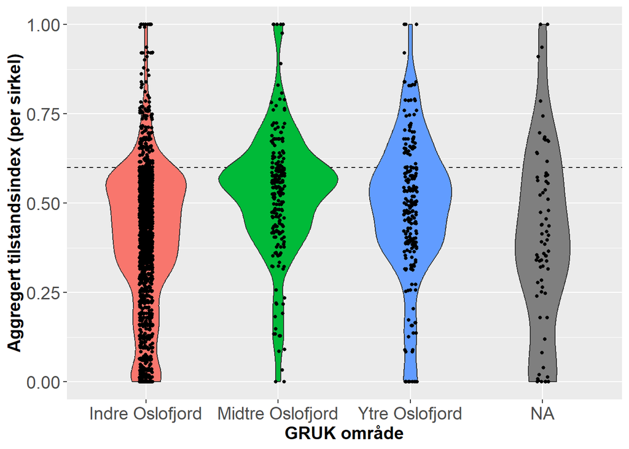

```r
####
# creating spatial objects for the bounding boxes
bokses <- data.frame(lon=c(241100,241100,270300,270300,
                           225000,225000,270300,270300,
                           184100,184100,214800,214800),
                     lat=c(6628000,6649700,6649700,6628000,
                           6590000,6621000,6621000,6590000,
                           6545000,6568700,6568700,6545000),
                     omr=c(rep('indre',4),rep('midtre',4),rep('ytre',4))
)

bokses <- bokses %>%
  st_as_sf(coords = c("lon", "lat"), remove=F, crs = 25833) %>%
  group_by(omr) %>%
  summarise(geometry = st_combine(geometry)) %>%
  st_cast("POLYGON")

# making the wide results object into a spatial object
res.natopen.GRUK_wide <- st_as_sf(res.natopen.GRUK_wide, coords = c("UTM33_E","UTM33_N"), remove=F, crs = 25833)
# adding region information
res.natopen.GRUK_wide <-  st_join(res.natopen.GRUK_wide, bokses)
res.natopen.GRUK_wide <-  st_drop_geometry(res.natopen.GRUK_wide)


#### plot ec.vs against område
res.natopen.GRUK_wide %>%
  ggplot(aes(x=omr,y=ec.vs,fill=omr)) +
  geom_hline(yintercept=0.6, linetype="dashed") +
  geom_violin()+
  geom_point(size=1, shape=16, color="black", position = position_jitter(seed = 1, width = 0.05)) +
  scale_x_discrete(labels=c('Indre Oslofjord', 'Midtre Oslofjord', 'Ytre Oslofjord') ) +
  xlab("GRUK område") +
  ylab("Aggregert tilstandsindex (per sirkel)") +
  theme(legend.position="none",
        axis.text.x = element_text(size=14),
        axis.text.y = element_text(size=14),
        axis.title=element_text(size=14,face="bold")
  )
```

Calculating an aggregated index for GRUK as a whole and for the three fjord areas (based on verste-styrer indices at circle level)

```r
## calculating an overall ec.index for GRUK
res.natopen.GRUK_wide <- res.natopen.GRUK_wide %>%
  mutate(ec.vs2 = ifelse(ec.vs < 0.001, 0.001, ec.vs) ) %>%
  mutate(ec.vs2 = ifelse(ec.vs2 > 0.999, 0.999, ec.vs2) )

# GRUK total
ec.total.vs <- glmmTMB(ec.vs2 ~ 1 +(1|LokalitetID/PolygonID), family=beta_family(), data=res.natopen.GRUK_wide)
summary(ec.total.vs)
```

```
##  Family: beta  ( logit )
## Formula:          ec.vs2 ~ 1 + (1 | LokalitetID/PolygonID)
## Data: res.natopen.GRUK_wide
##
##      AIC      BIC   logLik deviance df.resid
##   -829.2   -806.3    418.6   -837.2     2290
##
## Random effects:
##
## Conditional model:
##  Groups                Name        Variance Std.Dev.
##  PolygonID:LokalitetID (Intercept) 0.08457  0.2908
##  LokalitetID           (Intercept) 0.29582  0.5439
## Number of obs: 2294, groups:  PolygonID:LokalitetID, 227; LokalitetID, 115
##
## Dispersion parameter for beta family ():  3.8
##
## Conditional model:
##             Estimate Std. Error z value Pr(>|z|)
## (Intercept) -0.43993    0.06052  -7.269 3.63e-13 ***
## ---
## Signif. codes:  0 '***' 0.001 '**' 0.01 '*' 0.05 '.' 0.1 ' ' 1
```

```r
expit(summary(ec.total.vs)$coefficients$cond[1])
```

```
## [1] 0.3917582
```

```r
# fjord areas
ec.omr.vs <- glmmTMB(ec.vs2 ~ 0 + omr +(1|LokalitetID/PolygonID), family=beta_family(), data=res.natopen.GRUK_wide)
summary(ec.omr.vs)
```

```
##  Family: beta  ( logit )
## Formula:          ec.vs2 ~ 0 + omr + (1 | LokalitetID/PolygonID)
## Data: res.natopen.GRUK_wide
##
##      AIC      BIC   logLik deviance df.resid
##   -859.8   -825.6    435.9   -871.8     2214
##
## Random effects:
##
## Conditional model:
##  Groups                Name        Variance Std.Dev.
##  PolygonID:LokalitetID (Intercept) 0.09487  0.3080
##  LokalitetID           (Intercept) 0.24523  0.4952
## Number of obs: 2220, groups:  PolygonID:LokalitetID, 220; LokalitetID, 113
##
## Dispersion parameter for beta family (): 3.99
##
## Conditional model:
##           Estimate Std. Error z value Pr(>|z|)
## omrindre   -0.5663     0.0657  -8.620   <2e-16 ***
## omrmidtre   0.1265     0.1613   0.784    0.433
## omrytre    -0.1463     0.1823  -0.802    0.422
## ---
## Signif. codes:  0 '***' 0.001 '**' 0.01 '*' 0.05 '.' 0.1 ' ' 1
```

```r
expit(
  c(summary(ec.omr.vs)$coefficients$cond[1,1],
    summary(ec.omr.vs)$coefficients$cond[1,1]+summary(ec.omr.vs)$coefficients$cond[2,1],
    summary(ec.omr.vs)$coefficients$cond[1,1]+summary(ec.omr.vs)$coefficients$cond[3,1])
)
```

```
## [1] 0.3620838 0.3917832 0.3290172
```

For further visualizations of the single indicator results we need to re-arrange the results-objects from wide to long format (note that there is both a lower and an upper condition indicator for each of the functional plant indicators).

```r
#### scaled values by main ecosystem type ####

# make long version of the scaled value part
res.natopen.GRUK <-
  res.natopen.GRUK_wide %>%
  pivot_longer(
    cols = c("CC1","CC2",
             "SS1","SS2",
             "RR1","RR2",
             "Light1","Light2",
             "Nitrogen1","Nitrogen2",
             "Soil_disturbance1","Soil_disturbance2",
             "aliens","erosion","shrub"),
    names_to = "ec.index",
    values_to = "scaled_value",
    values_drop_na = FALSE
  )

# add original values as well
res.natopen.GRUK <-
  res.natopen.GRUK %>% add_column(original = results.natopen.GRUK[['original']] %>%
                                   pivot_longer(
                                     cols = c("CC1","CC2",
                                              "SS1","SS2",
                                              "RR1","RR2",
                                              "Light1","Light2",
                                              "Nitrogen1","Nitrogen2",
                                              "Soil_disturbance1","Soil_disturbance2",
                                              "aliens","erosion","shrub"),
                                     names_to = NULL,
                                     values_to = "original",
                                     values_drop_na = FALSE
                                   ) %>%
                                   pull(original)
  )

summary(res.natopen.GRUK)
```

```
##    PolygonID                                     GlobalID
##  122-2  :  900   00461807-03f2-4d12-a84e-58e2c819f23e:   30
##  123-4  :  600   00d3c6c8-5c55-4abd-a438-ad05d0f86eb8:   30
##  174-3  :  600   018452a6-58f6-4912-b6d9-8c19d53f62a6:   30
##  5-2    :  600   01996909-887d-48f5-86c8-c0b8209cb967:   30
##  75-1   :  600   02fa2994-7ead-4494-a2c2-2cf83dfd2440:   30
##  80-1   :  600   036b298d-96db-48a8-9f88-5b99dabdfd91:   30
##  (Other):30510   (Other)                             :34230
##     RuteID          RuteID_loknr       Dekning_karplanter_feltsjikt
##  Length:34410       Length:34410       Min.   :  0.00
##  Class :character   Class :character   1st Qu.: 20.00
##  Mode  :character   Mode  :character   Median : 40.00
##                                        Mean   : 43.23
##                                        3rd Qu.: 65.00
##                                        Max.   :100.00
##
##  Dekning_moser     Dekning_lav      Dekning_strø   Dekning_bar_substrat
##  Min.   :  0.00   Min.   : 0.000   Min.   : 0.00   Min.   :  0.00
##  1st Qu.:  4.00   1st Qu.: 0.000   1st Qu.: 2.00   1st Qu.:  0.10
##  Median : 20.00   Median : 0.000   Median : 6.00   Median :  8.00
##  Mean   : 28.67   Mean   : 2.095   Mean   :18.67   Mean   : 23.84
##  3rd Qu.: 50.00   3rd Qu.: 1.000   3rd Qu.:20.00   3rd Qu.: 40.00
##  Max.   :100.00   Max.   :88.000   Max.   :99.00   Max.   :100.00
##
##   Precision           UTM33_E_ne       UTM33_N_ne        UTM33_E_sw
##  Length:34410       Min.   :  -Inf   Min.   :   -Inf   Min.   :  -Inf
##  Class :character   1st Qu.:248877   1st Qu.:6639271   1st Qu.:248657
##  Mode  :character   Median :252928   Median :6644422   Median :252714
##                     Mean   :  -Inf   Mean   :   -Inf   Mean   :  -Inf
##                     3rd Qu.:258102   3rd Qu.:6646990   3rd Qu.:257581
##                     Max.   :263106   Max.   :6649626   Max.   :263106
##
##    UTM33_N_sw        areal_m2            UTM33_N           UTM33_E
##  Min.   :   -Inf   Length:34410       Min.   :   -Inf   Min.   :  -Inf
##  1st Qu.:6638998   Class :character   1st Qu.:6638011   1st Qu.:248655
##  Median :6644417   Mode  :character   Median :6644416   Median :252706
##  Mean   :   -Inf                      Mean   :   -Inf   Mean   :  -Inf
##  3rd Qu.:6646980                      3rd Qu.:6646980   3rd Qu.:257571
##  Max.   :6649626                      Max.   :6649626   Max.   :263106
##
```

[output cut: 41 more lines]

```
##  Min.   :0.2628   Min.   :0.2165   Min.   :0.0000   Length:34410
##  1st Qu.:0.6742   1st Qu.:0.7298   1st Qu.:0.3192   Class :character
##  Median :0.7510   Median :0.8007   Median :0.4480   Mode  :character
##  Mean   :0.7447   Mean   :0.7794   Mean   :0.4249
##  3rd Qu.:0.8304   3rd Qu.:0.8546   3rd Qu.:0.5645
##  Max.   :1.0000   Max.   :0.9999   Max.   :1.0000
##
##      ec.vs2         ec.index          scaled_value      original
##  Min.   :0.0010   Length:34410       Min.   :0.000   Min.   :  0.0000
##  1st Qu.:0.3192   Class :character   1st Qu.:0.579   1st Qu.:  0.3774
##  Median :0.4480   Mode  :character   Median :0.786   Median :  3.4149
##  Mean   :0.4249                      Mean   :0.738   Mean   : 21.3309
##  3rd Qu.:0.5645                      3rd Qu.:0.951   3rd Qu.:  6.2761
##  Max.   :0.9990                      Max.   :1.000   Max.   :100.0000
##                                      NA's   :14963   NA's   :2398
```

```r
res.natopen.GRUK <- res.natopen.GRUK %>%
  mutate(Dekning_problemarter = as.numeric(Dekning_problemarter))
summary(res.natopen.GRUK)
```

```
##    PolygonID                                     GlobalID
##  122-2  :  900   00461807-03f2-4d12-a84e-58e2c819f23e:   30
##  123-4  :  600   00d3c6c8-5c55-4abd-a438-ad05d0f86eb8:   30
##  174-3  :  600   018452a6-58f6-4912-b6d9-8c19d53f62a6:   30
##  5-2    :  600   01996909-887d-48f5-86c8-c0b8209cb967:   30
##  75-1   :  600   02fa2994-7ead-4494-a2c2-2cf83dfd2440:   30
##  80-1   :  600   036b298d-96db-48a8-9f88-5b99dabdfd91:   30
##  (Other):30510   (Other)                             :34230
##     RuteID          RuteID_loknr       Dekning_karplanter_feltsjikt
##  Length:34410       Length:34410       Min.   :  0.00
##  Class :character   Class :character   1st Qu.: 20.00
##  Mode  :character   Mode  :character   Median : 40.00
##                                        Mean   : 43.23
##                                        3rd Qu.: 65.00
##                                        Max.   :100.00
##
##  Dekning_moser     Dekning_lav      Dekning_strø   Dekning_bar_substrat
##  Min.   :  0.00   Min.   : 0.000   Min.   : 0.00   Min.   :  0.00
##  1st Qu.:  4.00   1st Qu.: 0.000   1st Qu.: 2.00   1st Qu.:  0.10
##  Median : 20.00   Median : 0.000   Median : 6.00   Median :  8.00
##  Mean   : 28.67   Mean   : 2.095   Mean   :18.67   Mean   : 23.84
##  3rd Qu.: 50.00   3rd Qu.: 1.000   3rd Qu.:20.00   3rd Qu.: 40.00
##  Max.   :100.00   Max.   :88.000   Max.   :99.00   Max.   :100.00
##
##   Precision           UTM33_E_ne       UTM33_N_ne        UTM33_E_sw
##  Length:34410       Min.   :  -Inf   Min.   :   -Inf   Min.   :  -Inf
##  Class :character   1st Qu.:248877   1st Qu.:6639271   1st Qu.:248657
##  Mode  :character   Median :252928   Median :6644422   Median :252714
##                     Mean   :  -Inf   Mean   :   -Inf   Mean   :  -Inf
##                     3rd Qu.:258102   3rd Qu.:6646990   3rd Qu.:257581
##                     Max.   :263106   Max.   :6649626   Max.   :263106
##
##    UTM33_N_sw        areal_m2            UTM33_N           UTM33_E
##  Min.   :   -Inf   Length:34410       Min.   :   -Inf   Min.   :  -Inf
##  1st Qu.:6638998   Class :character   1st Qu.:6638011   1st Qu.:248655
##  Median :6644417   Mode  :character   Median :6644416   Median :252706
##  Mean   :   -Inf                      Mean   :   -Inf   Mean   :  -Inf
##  3rd Qu.:6646980                      3rd Qu.:6646980   3rd Qu.:257571
##  Max.   :6649626                      Max.   :6649626   Max.   :263106
##
```

[output cut: 41 more lines]

```
##  Min.   :0.2628   Min.   :0.2165   Min.   :0.0000   Length:34410
##  1st Qu.:0.6742   1st Qu.:0.7298   1st Qu.:0.3192   Class :character
##  Median :0.7510   Median :0.8007   Median :0.4480   Mode  :character
##  Mean   :0.7447   Mean   :0.7794   Mean   :0.4249
##  3rd Qu.:0.8304   3rd Qu.:0.8546   3rd Qu.:0.5645
##  Max.   :1.0000   Max.   :0.9999   Max.   :1.0000
##
##      ec.vs2         ec.index          scaled_value      original
##  Min.   :0.0010   Length:34410       Min.   :0.000   Min.   :  0.0000
##  1st Qu.:0.3192   Class :character   1st Qu.:0.579   1st Qu.:  0.3774
##  Median :0.4480   Mode  :character   Median :0.786   Median :  3.4149
##  Mean   :0.4249                      Mean   :0.738   Mean   : 21.3309
##  3rd Qu.:0.5645                      3rd Qu.:0.951   3rd Qu.:  6.2761
##  Max.   :0.9990                      Max.   :1.000   Max.   :100.0000
##                                      NA's   :14963   NA's   :2398
```

### Ecologcial condition indicators

We can show the resulting scaled values as Violin plots for each the circle-based indicators

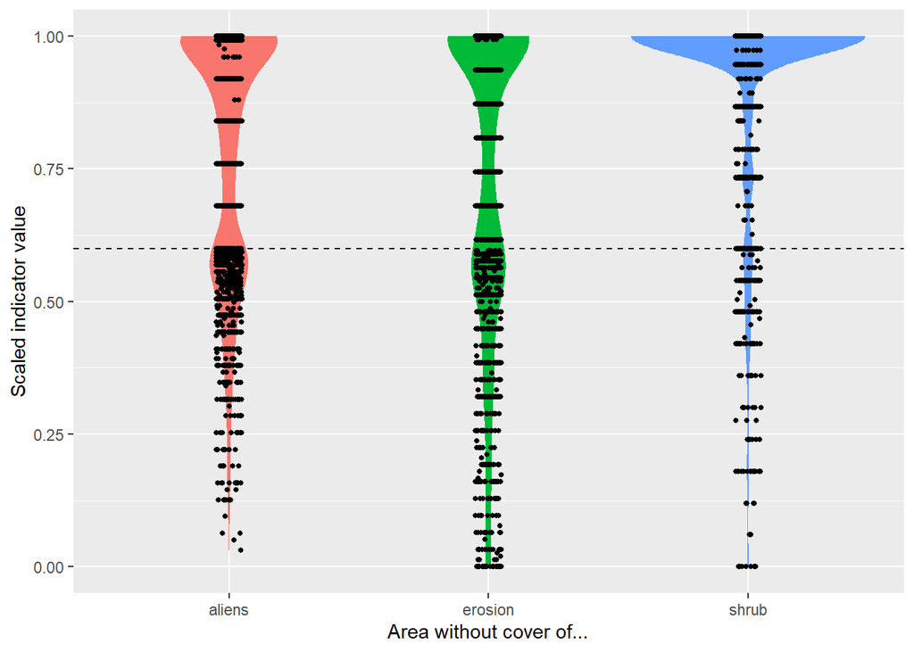

```r
# English
res.natopen.GRUK %>%
  filter(ec.index %in% c("aliens","erosion","shrub")) %>%
  ggplot(aes(x=ec.index,y=scaled_value, fill=ec.index)) +
  geom_hline(yintercept=0.6, linetype="dashed") +
  geom_violin(color=NA)+
  geom_point(size=1, shape=16, color="black", position = position_jitter(seed = 1, width = 0.05)) +
  xlab("Area without cover of...") +
  ylab("Scaled indicator value") +
  theme(legend.position="none")
```

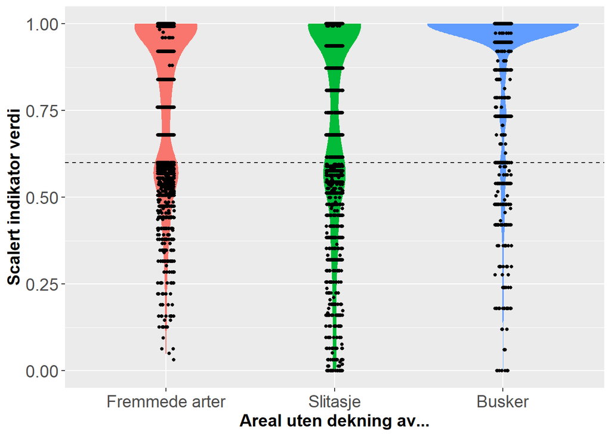

```r
# Norsk
res.natopen.GRUK %>%
  filter(ec.index %in% c("aliens","erosion","shrub")) %>%
  ggplot(aes(x=ec.index,y=scaled_value, fill=ec.index)) +
  geom_hline(yintercept=0.6, linetype="dashed") +
  geom_violin(color=NA)+
  geom_point(size=1, shape=16, color="black", position = position_jitter(seed = 1, width = 0.05)) +
  scale_x_discrete(labels=c('Fremmede arter', 'Slitasje', 'Busker') ) +
  xlab("Areal uten dekning av...") +
  ylab("Scalert indikator verdi") +
  theme(legend.position="none",
        axis.text.x = element_text(size=14),
        axis.text.y = element_text(size=14),
        axis.title=element_text(size=14,face="bold"))
```

We can show the resulting scaled values for the functional plant indicators as Violin plots for each plant indicator in both T2-C7 and T2-C8 or for GRUK alltogether

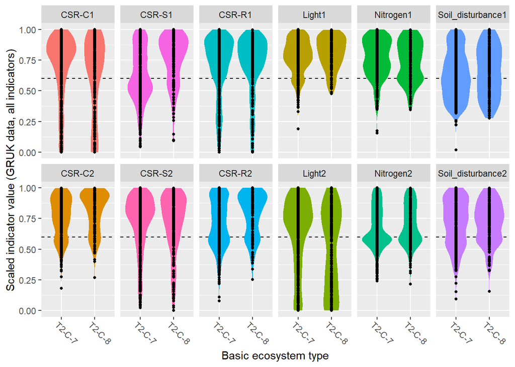

```r
# plotting scaled values by ecosystem type
res.natopen.GRUK %>%
  filter(ec.index %in% c("CC1","SS1","RR1","Light1","Nitrogen1","Soil_disturbance1",
                         "CC2","SS2","RR2","Light2","Nitrogen2","Soil_disturbance2")) %>%
ggplot(aes(x=factor(Kartleggingsenhet_1til5000), y=scaled_value, fill=ec.index)) +
  geom_hline(yintercept=0.6, linetype="dashed") +
  geom_violin(color = NA) +
  #  geom_boxplot(width=0.2, color="grey") +
  geom_point(size=1, shape=16, color="black") +
  facet_wrap(~factor(ec.index,levels=c("CC1","SS1","RR1","Light1","Nitrogen1","Soil_disturbance1",
                                     "CC2","SS2","RR2","Light2","Nitrogen2","Soil_disturbance2"),
                     labels=c("CSR-C1","CSR-S1","CSR-R1","Light1","Nitrogen1","Soil_disturbance1",
                              "CSR-C2","CSR-S2","CSR-R2","Light2","Nitrogen2","Soil_disturbance2")), ncol = 6) +
  xlab("Basic ecosystem type") +
  ylab("Scaled indicator value (GRUK data, all indicators)") +
  theme(legend.position="none") +
  theme(axis.text.x = element_text(angle = -45, vjust = 0.5, hjust=0.2))
```

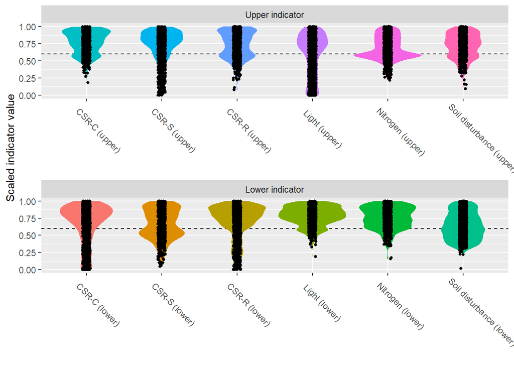

```r
# all GRUK, English
res.natopen.GRUK %>%
  filter(ec.index %in% c("CC1","SS1","RR1","Light1","Nitrogen1","Soil_disturbance1",
                         "CC2","SS2","RR2","Light2","Nitrogen2","Soil_disturbance2")) %>%
  mutate(dir= recode(ec.index,CC1="lower",SS1="lower",RR1="lower",Light1="lower",Nitrogen1="lower",Soil_disturbance1="lower",
                         CC2="upper",SS2="upper",RR2="upper",Light2="upper",Nitrogen2="upper",Soil_disturbance2="upper")) %>%
    mutate(ec.index= recode(ec.index,CC1="CSR-C (lower)",SS1="CSR-S (lower)",RR1="CSR-R (lower)",Light1="Light (lower)",Nitrogen1="Nitrogen (lower)",Soil_disturbance1="Soil disturbance (lower)",
                         CC2="CSR-C (upper)",SS2="CSR-S (upper)",RR2="CSR-R (upper)",Light2="Light (upper)",Nitrogen2="Nitrogen (upper)",Soil_disturbance2="Soil disturbance (upper)")) %>%
  mutate(dir = factor(dir,levels=c("upper","lower")) ) %>%
    mutate(ec.index = factor(ec.index,levels=c("CSR-C (lower)","CSR-S (lower)","CSR-R (lower)","Light (lower)","Nitrogen (lower)","Soil disturbance (lower)",
                         "CSR-C (upper)","CSR-S (upper)","CSR-R (upper)","Light (upper)","Nitrogen (upper)","Soil disturbance (upper)")) ) %>%
  ggplot(aes(x=ec.index, y=scaled_value, fill=ec.index)) +
  geom_hline(yintercept=0.6, linetype="dashed") +
  geom_violin(color = NA) +
  #  geom_boxplot(width=0.2, color="grey") +
  geom_point(size=1, shape=16, color="black", position = position_jitter(seed = 1, width = 0.05)) +
  facet_wrap(~dir, nrow = 2, , scale="free", labeller = labeller(dir = c("upper"="Upper indicator", "lower"="Lower indicator"))) +
  xlab("") +
  ylab("Scaled indicator value") +
  theme(legend.position="none") +
  theme(axis.text.x = element_text(angle = -45, vjust = 0.5, hjust=0.2))
```

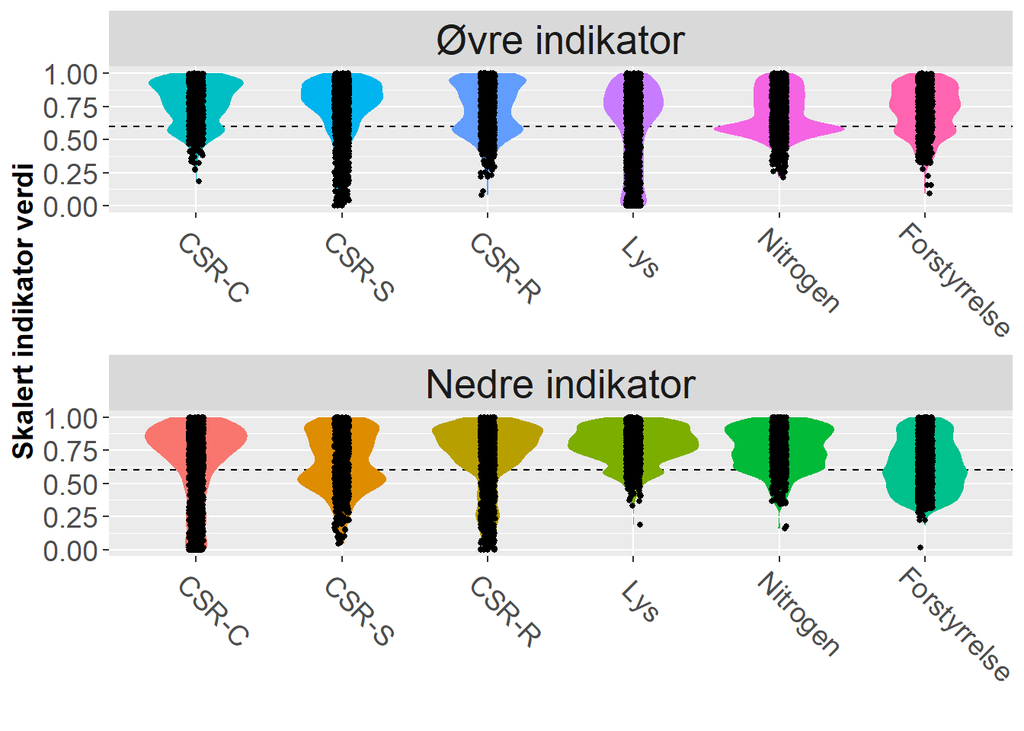

```r
# all GRUK, Norsk
res.natopen.GRUK %>%
  filter(ec.index %in% c("CC1","SS1","RR1","Light1","Nitrogen1","Soil_disturbance1",
                         "CC2","SS2","RR2","Light2","Nitrogen2","Soil_disturbance2")) %>%
  mutate(dir= recode(ec.index,CC1="lower",SS1="lower",RR1="lower",Light1="lower",Nitrogen1="lower",Soil_disturbance1="lower",
                     CC2="upper",SS2="upper",RR2="upper",Light2="upper",Nitrogen2="upper",Soil_disturbance2="upper")) %>%
  mutate(ec.index= recode(ec.index,CC1="CSR-C (lower)",SS1="CSR-S (lower)",RR1="CSR-R (lower)",Light1="Light (lower)",Nitrogen1="Nitrogen (lower)",Soil_disturbance1="Soil disturbance (lower)",
                          CC2="CSR-C (upper)",SS2="CSR-S (upper)",RR2="CSR-R (upper)",Light2="Light (upper)",Nitrogen2="Nitrogen (upper)",Soil_disturbance2="Soil disturbance (upper)")) %>%
  mutate(dir = factor(dir,levels=c("upper","lower")) ) %>%
  mutate(ec.index = factor(ec.index,levels=c("CSR-C (lower)","CSR-S (lower)","CSR-R (lower)","Light (lower)","Nitrogen (lower)","Soil disturbance (lower)",
                                             "CSR-C (upper)","CSR-S (upper)","CSR-R (upper)","Light (upper)","Nitrogen (upper)","Soil disturbance (upper)")) ) %>%
  ggplot(aes(x=ec.index, y=scaled_value, fill=ec.index)) +
  geom_hline(yintercept=0.6, linetype="dashed") +
  geom_violin(color = NA) +
  #  geom_boxplot(width=0.2, color="grey") +
  geom_point(size=1, shape=16, color="black", position = position_jitter(seed = 1, width = 0.05)) +
  facet_wrap(~dir, nrow = 2, , scale="free", labeller = labeller(dir = c("upper"="Øvre indikator", "lower"="Nedre indikator"))) +
  scale_x_discrete(labels=c('CSR-C', 'CSR-S', 'CSR-R', 'Lys', 'Nitrogen', 'Forstyrrelse',
                            'CSR-C', 'CSR-S', 'CSR-R', 'Lys', 'Nitrogen', 'Forstyrrelse') ) +
  xlab("") +
  ylab("Skalert indikator verdi") +
  theme(legend.position="none",
        axis.text.x = element_text(angle = -45, vjust = 0.5, hjust=0.2, size=14),
        axis.text.y = element_text(size=14),
        axis.title=element_text(size=14,face="bold"),
        strip.text = element_text(size = 20)
        )
```

Aggregated condition index against polygon assessment

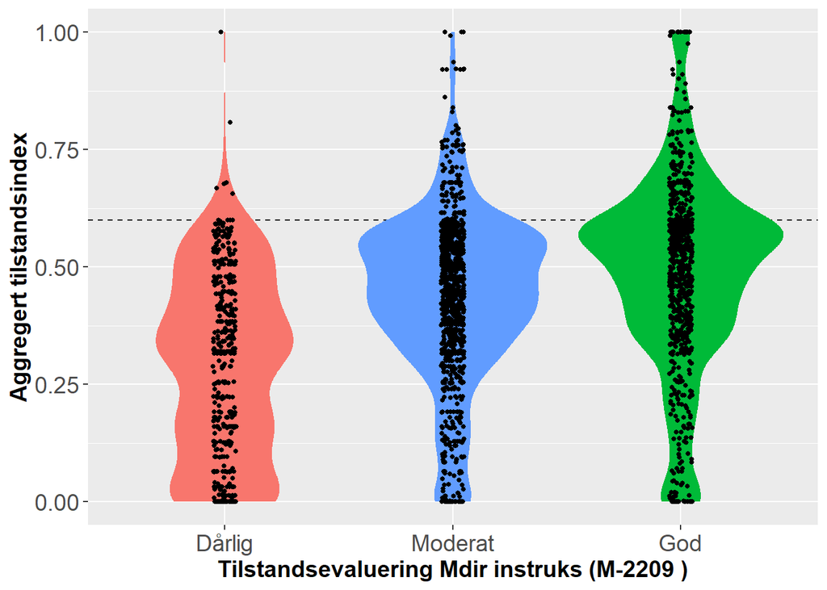

```r
res.natopen.GRUK_wide %>%
  ggplot(aes(x=factor(Tilstand,levels=c("Dårlig","Moderat","God")),y=ec.vs, fill=Tilstand)) +
  geom_hline(yintercept=0.6, linetype="dashed") +
  geom_violin(color=NA)+
  geom_point(size=1, shape=16, color="black", position = position_jitter(seed = 1, width = 0.05)) +
  xlab("Tilstandsevaluering Mdir instruks (M-2209 )") +
  ylab("Aggregert tilstandsindex") +
  theme(legend.position="none",
        axis.text.x = element_text(size=14),
        axis.text.y = element_text(size=14),
        axis.title=element_text(size=14,face="bold")
        )
```

We can test if the functional plant indicator indices correlate with the circle based indicator data

```r
x <- c("erosjon_prosent","Dekning_busker_busksjikt","Dekning_tresjikt","Dekning_problemarter" ,"Totaldekning_fremmedearter")
y1 <- c("CC1","CC2","SS1","SS2","RR1","RR2")
y2 <- c("Light1","Light2","Nitrogen1","Nitrogen2","Soil_disturbance1","Soil_disturbance2")


par(mfrow=c(5,6))
for (i in x) {
  for (j in y1) {
    df <- res.natopen.GRUK[res.natopen.GRUK$ec.index==j,c(i,'scaled_value')]
    names(df) <- c("xx","yy")
    df$xx <- as.numeric(df$xx)
    df$yy <- as.numeric(df$yy)
    df[!is.na(df$yy) & df$yy==1,"yy"] <- 0.9999
    df[!is.na(df$yy) & df$yy==0,"yy"] <- 0.0001
    with(df, plot(xx,yy,xlab=i,ylab=j, xlim=c(0,115), ylim=c(0,1)) )
    mod <- with(df, betareg(yy~xx))
    points(0:100,predict(mod,newdata=data.frame(xx=0:100),type='response'),col="red",type="l")
    text(110,0.1,labels=paste(round(summary(mod)$coefficients$mean[2,4],digits=3)), col="red")
  }
}

par(mfrow=c(5,6))
for (i in x) {
  for (j in y2) {
    df <- res.natopen.GRUK[res.natopen.GRUK$ec.index==j,c(i,'scaled_value')]
    names(df) <- c("xx","yy")
    df$xx <- as.numeric(df$xx)
    df$yy <- as.numeric(df$yy)
    df[!is.na(df$yy) & df$yy==1,"yy"] <- 0.9999
    df[!is.na(df$yy) & df$yy==0,"yy"] <- 0.0001
    with(df, plot(xx,yy,xlab=i,ylab=j, xlim=c(0,115), ylim=c(0,1)) )
    mod <- with(df, betareg(yy~xx))
    points(0:100,predict(mod,newdata=data.frame(xx=0:100),type='response'),col="red",type="l")
    text(110,0.1,labels=paste(round(summary(mod)$coefficients$mean[2,4],digits=3)), col="red")
  }
}
```

[output not shown]

From this overview we focus on negative trends (i.e. condition variables increase towards worse and condition indicators decrease towards worse) and build more appropriate models taking the data structure into account

```r
res.natopen.GRUK <- res.natopen.GRUK %>%
  mutate(scaled_value2 = ifelse(scaled_value < 0.001, 0.001, scaled_value) ) %>%
  mutate(scaled_value2 = ifelse(scaled_value2 > 0.999, 0.999, scaled_value2) )


summary( glmmTMB(scaled_value2 ~ Dekning_tresjikt +(1|LokalitetID), family=beta_family(), data=res.natopen.GRUK[res.natopen.GRUK$ec.index=="Light1",]) )
```

```
##  Family: beta  ( logit )
## Formula:          scaled_value2 ~ Dekning_tresjikt + (1 | LokalitetID)
## Data: res.natopen.GRUK[res.natopen.GRUK$ec.index == "Light1", ]
##
##      AIC      BIC   logLik deviance df.resid
##  -1306.6  -1287.1    657.3  -1314.6      975
##
## Random effects:
##
## Conditional model:
##  Groups      Name        Variance Std.Dev.
##  LokalitetID (Intercept) 0.08707  0.2951
## Number of obs: 979, groups:  LokalitetID, 111
##
## Dispersion parameter for beta family (): 8.09
##
## Conditional model:
##                   Estimate Std. Error z value Pr(>|z|)
## (Intercept)       1.413157   0.046111  30.647  < 2e-16 ***
## Dekning_tresjikt -0.009952   0.001976  -5.036 4.75e-07 ***
## ---
## Signif. codes:  0 '***' 0.001 '**' 0.01 '*' 0.05 '.' 0.1 ' ' 1
```

```r
summary( glmmTMB(scaled_value2 ~ erosjon_prosent +(1|LokalitetID), family=beta_family(), data=res.natopen.GRUK[res.natopen.GRUK$ec.index=="Light2",]) )
```

```
##  Family: beta  ( logit )
## Formula:          scaled_value2 ~ erosjon_prosent + (1 | LokalitetID)
## Data: res.natopen.GRUK[res.natopen.GRUK$ec.index == "Light2", ]
##
##      AIC      BIC   logLik deviance df.resid
##   -247.9   -227.7    128.0   -255.9     1160
##
## Random effects:
##
## Conditional model:
##  Groups      Name        Variance Std.Dev.
##  LokalitetID (Intercept) 0.2269   0.4763
## Number of obs: 1164, groups:  LokalitetID, 112
##
## Dispersion parameter for beta family (): 1.66
##
## Conditional model:
##                  Estimate Std. Error z value Pr(>|z|)
## (Intercept)      0.262258   0.067000   3.914 9.07e-05 ***
## erosjon_prosent -0.006741   0.001826  -3.691 0.000223 ***
## ---
## Signif. codes:  0 '***' 0.001 '**' 0.01 '*' 0.05 '.' 0.1 ' ' 1
```

```r
summary( glmmTMB(scaled_value2 ~ Totaldekning_fremmedearter +(1|LokalitetID), family=beta_family(), data=res.natopen.GRUK[res.natopen.GRUK$ec.index=="Nitrogen2",]) )
```

```
##  Family: beta  ( logit )
## Formula:
## scaled_value2 ~ Totaldekning_fremmedearter + (1 | LokalitetID)
## Data: res.natopen.GRUK[res.natopen.GRUK$ec.index == "Nitrogen2", ]
##
##      AIC      BIC   logLik deviance df.resid
##  -1152.9  -1132.0    580.5  -1160.9     1390
##
## Random effects:
##
## Conditional model:
##  Groups      Name        Variance Std.Dev.
##  LokalitetID (Intercept) 0.1414   0.3761
## Number of obs: 1394, groups:  LokalitetID, 111
##
## Dispersion parameter for beta family (): 6.59
##
## Conditional model:
##                             Estimate Std. Error z value Pr(>|z|)
## (Intercept)                 0.889196   0.046258  19.223  < 2e-16 ***
## Totaldekning_fremmedearter -0.005389   0.001631  -3.303 0.000957 ***
## ---
## Signif. codes:  0 '***' 0.001 '**' 0.01 '*' 0.05 '.' 0.1 ' ' 1
```

```r
summary( glmmTMB(scaled_value2 ~ Dekning_tresjikt +(1|LokalitetID), family=beta_family(), data=res.natopen.GRUK[res.natopen.GRUK$ec.index=="Soil_disturbance1",]) )
```

```
##  Family: beta  ( logit )
## Formula:          scaled_value2 ~ Dekning_tresjikt + (1 | LokalitetID)
## Data: res.natopen.GRUK[res.natopen.GRUK$ec.index == "Soil_disturbance1",      ]
##
##      AIC      BIC   logLik deviance df.resid
##   -785.9   -764.8    397.0   -793.9     1456
##
## Random effects:
##
## Conditional model:
##  Groups      Name        Variance Std.Dev.
##  LokalitetID (Intercept) 0.1196   0.3458
## Number of obs: 1460, groups:  LokalitetID, 111
##
## Dispersion parameter for beta family (): 5.02
##
## Conditional model:
##                   Estimate Std. Error z value Pr(>|z|)
## (Intercept)       0.736903   0.045621   16.15  < 2e-16 ***
## Dekning_tresjikt -0.007241   0.001978   -3.66 0.000252 ***
## ---
## Signif. codes:  0 '***' 0.001 '**' 0.01 '*' 0.05 '.' 0.1 ' ' 1
```

```r
summary( glmmTMB(scaled_value2 ~ Dekning_problemarter +(1|LokalitetID), family=beta_family(), data=res.natopen.GRUK[res.natopen.GRUK$ec.index=="Soil_disturbance2",]) )
```

```
##  Family: beta  ( logit )
## Formula:          scaled_value2 ~ Dekning_problemarter + (1 | LokalitetID)
## Data: res.natopen.GRUK[res.natopen.GRUK$ec.index == "Soil_disturbance2",      ]
##
##      AIC      BIC   logLik deviance df.resid
##   -418.3   -401.1    213.2   -426.3      546
##
## Random effects:
##
## Conditional model:
##  Groups      Name        Variance Std.Dev.
##  LokalitetID (Intercept) 0.0941   0.3068
## Number of obs: 550, groups:  LokalitetID, 94
##
## Dispersion parameter for beta family (): 5.33
##
## Conditional model:
##                       Estimate Std. Error z value Pr(>|z|)
## (Intercept)           0.993208   0.055035  18.047   <2e-16 ***
## Dekning_problemarter -0.011119   0.004695  -2.369   0.0179 *
## ---
## Signif. codes:  0 '***' 0.001 '**' 0.01 '*' 0.05 '.' 0.1 ' ' 1
```

```r
summary( glmmTMB(scaled_value2 ~ Totaldekning_fremmedearter +(1|LokalitetID), family=beta_family(), data=res.natopen.GRUK[res.natopen.GRUK$ec.index=="CC2",]) )
```

```
##  Family: beta  ( logit )
## Formula:
## scaled_value2 ~ Totaldekning_fremmedearter + (1 | LokalitetID)
## Data: res.natopen.GRUK[res.natopen.GRUK$ec.index == "CC2", ]
##
##      AIC      BIC   logLik deviance df.resid
##   -966.4   -947.3    487.2   -974.4      870
##
## Random effects:
##
## Conditional model:
##  Groups      Name        Variance Std.Dev.
##  LokalitetID (Intercept) 0.1098   0.3313
## Number of obs: 874, groups:  LokalitetID, 109
##
## Dispersion parameter for beta family (): 5.93
##
## Conditional model:
##                             Estimate Std. Error z value Pr(>|z|)
## (Intercept)                 1.272937   0.051000  24.960   <2e-16 ***
## Totaldekning_fremmedearter -0.001976   0.002160  -0.915     0.36
## ---
## Signif. codes:  0 '***' 0.001 '**' 0.01 '*' 0.05 '.' 0.1 ' ' 1
```

```r
summary( glmmTMB(scaled_value2 ~ Dekning_problemarter +(1|LokalitetID), family=beta_family(), data=res.natopen.GRUK[res.natopen.GRUK$ec.index=="CC2",]) )
```

```
##  Family: beta  ( logit )
## Formula:          scaled_value2 ~ Dekning_problemarter + (1 | LokalitetID)
## Data: res.natopen.GRUK[res.natopen.GRUK$ec.index == "CC2", ]
##
##      AIC      BIC   logLik deviance df.resid
##   -617.6   -600.2    312.8   -625.6      569
##
## Random effects:
##
## Conditional model:
##  Groups      Name        Variance Std.Dev.
##  LokalitetID (Intercept) 0.1153   0.3395
## Number of obs: 573, groups:  LokalitetID, 93
##
## Dispersion parameter for beta family (): 5.99
##
## Conditional model:
##                       Estimate Std. Error z value Pr(>|z|)
## (Intercept)           1.281492   0.056936  22.508   <2e-16 ***
## Dekning_problemarter -0.008462   0.004202  -2.014    0.044 *
## ---
## Signif. codes:  0 '***' 0.001 '**' 0.01 '*' 0.05 '.' 0.1 ' ' 1
```

Plotting relevant scatterplots and models

```r
## Light1 vs. Dekning__busker_busksjikt
# basic scatterplot
p_L1_busk <- res.natopen.GRUK %>%
  filter(ec.index=="Light1") %>%
  ggplot(aes(x=Dekning_busker_busksjikt, y=scaled_value)) +
  geom_point() +
  coord_cartesian(xlim = c(0, 100),ylim = c(0, 1)) +
  labs(y = "Lys (nedre)", x = "Busksjiktsdekning (%)") +
  theme(legend.position="none",
        axis.text.x = element_text(size=14),
        axis.text.y = element_text(size=14),
        axis.title=element_text(size=14,face="bold")
        )

# model and model prediction
mod <- glmmTMB(scaled_value2 ~ Dekning_busker_busksjikt +(1|LokalitetID), family=beta_family(), data=res.natopen.GRUK[res.natopen.GRUK$ec.index=="Light1",])
pred <- data.frame(
  mu = predict(mod,newdata=data.frame(Dekning_busker_busksjikt=0:100),type='link',re.form=NA),
  se = predict(mod,newdata=data.frame(Dekning_busker_busksjikt=0:100),type='link',re.form=NA,se.fit=T)$se.fit
)
pred <- pred %>%
  mutate(ci.lo = mu-1.96*se,
         ci.hi = mu+1.96*se)

# expit function for backtransforming from logit-link
expit <- function(L) exp(L) / (1+exp(L))

# add model line and 95%-CI to scatterplot
p_L1_busk <- p_L1_busk +
  geom_line(data=data.frame(x=0:100,y=expit(pred$mu)), aes(x,y),col="firebrick",linewidth=2) +
  geom_ribbon(data = pred, aes(x= 0:100, y = mu, ymin = expit(ci.lo), ymax = expit(ci.hi)), alpha = 0.3, fill = "firebrick") +
  #  annotate("text",x=90, y=0.1, label=paste("p = ",round(summary(mod)$coefficients$cond[2,4],6)), size=6, col="firebrick" ) +
  annotate("text",x=90, y=0.1, label=paste("p < 0.01"), size=6, col="firebrick" )


## Light2 vs. erosjon_prosent
# basic scatterplot
p_L2_slit <- res.natopen.GRUK %>%
  filter(ec.index=="Light2") %>%
  ggplot(aes(x=erosjon_prosent, y=scaled_value)) +
  geom_point() +
  coord_cartesian(xlim = c(0, 100),ylim = c(0, 1)) +
  labs(y = "Lys (øvre)", x = "Slitasjedekning (%)") +
  theme(legend.position="none",
        axis.text.x = element_text(size=14),
        axis.text.y = element_text(size=14),
        axis.title=element_text(size=14,face="bold")
  )

# model and model prediction
mod <- glmmTMB(scaled_value2 ~ erosjon_prosent +(1|LokalitetID), family=beta_family(), data=res.natopen.GRUK[res.natopen.GRUK$ec.index=="Light2",])
pred <- data.frame(
  mu = predict(mod,newdata=data.frame(erosjon_prosent=0:100),type='link',re.form=NA),
  se = predict(mod,newdata=data.frame(erosjon_prosent=0:100),type='link',re.form=NA,se.fit=T)$se.fit
)
pred <- pred %>%
  mutate(ci.lo = mu-1.96*se,
         ci.hi = mu+1.96*se)

# expit function for backtransforming from logit-link
expit <- function(L) exp(L) / (1+exp(L))

# add model line and 95%-CI to scatterplot
p_L2_slit <- p_L2_slit +
  geom_line(data=data.frame(x=0:100,y=expit(pred$mu)), aes(x,y),col="firebrick",linewidth=2) +
  geom_ribbon(data = pred, aes(x= 0:100, y = mu, ymin = expit(ci.lo), ymax = expit(ci.hi)), alpha = 0.3, fill = "firebrick") +
  #  annotate("text",x=90, y=0.1, label=paste("p = ",round(summary(mod)$coefficients$cond[2,4],6)), size=6, col="firebrick" ) +
  annotate("text",x=90, y=0.1, label=paste("p < 0.01"), size=6, col="firebrick" )

## Nitrogen2 vs. Totaldekning_fremmedearter
# basic scatterplot
p_N2_frem <- res.natopen.GRUK %>%
  filter(ec.index=="Nitrogen2") %>%
  ggplot(aes(x=Totaldekning_fremmedearter, y=scaled_value)) +
  geom_point() +
  coord_cartesian(xlim = c(0, 100),ylim = c(0, 1)) +
  labs(y = "Nitrogen (øvre)", x = "Fremmedartsdekning (%)") +
  theme(legend.position="none",
        axis.text.x = element_text(size=14),
        axis.text.y = element_text(size=14),
        axis.title=element_text(size=14,face="bold")
  )

# model and model prediction
mod <- glmmTMB(scaled_value2 ~ Totaldekning_fremmedearter +(1|LokalitetID), family=beta_family(), data=res.natopen.GRUK[res.natopen.GRUK$ec.index=="Nitrogen2",])
pred <- data.frame(
  mu = predict(mod,newdata=data.frame(Totaldekning_fremmedearter=0:100),type='link',re.form=NA),
  se = predict(mod,newdata=data.frame(Totaldekning_fremmedearter=0:100),type='link',re.form=NA,se.fit=T)$se.fit
)
pred <- pred %>%
  mutate(ci.lo = mu-1.96*se,
         ci.hi = mu+1.96*se)

# expit function for backtransforming from logit-link
expit <- function(L) exp(L) / (1+exp(L))

# add model line and 95%-CI to scatterplot
p_N2_frem <- p_N2_frem +
  geom_line(data=data.frame(x=0:100,y=expit(pred$mu)), aes(x,y),col="firebrick",linewidth=2) +
  geom_ribbon(data = pred, aes(x= 0:100, y = mu, ymin = expit(ci.lo), ymax = expit(ci.hi)), alpha = 0.3, fill = "firebrick") +
  #  annotate("text",x=90, y=0.1, label=paste("p = ",round(summary(mod)$coefficients$cond[2,4],6)), size=6, col="firebrick" ) +
  annotate("text",x=90, y=0.1, label=paste("p < 0.01"), size=6, col="firebrick" )

## Soil_disturbance1 vs. Dekning_busker_busksjikt
# basic scatterplot
p_Sd1_busk <- res.natopen.GRUK %>%
  filter(ec.index=="Soil_disturbance1") %>%
  ggplot(aes(x=Dekning_busker_busksjikt, y=scaled_value)) +
  geom_point() +
  coord_cartesian(xlim = c(0, 100),ylim = c(0, 1)) +
  labs(y = "Forstyrrelse (nedre)", x = "Busksjiktsdekning (%)") +
  theme(legend.position="none",
        axis.text.x = element_text(size=14),
        axis.text.y = element_text(size=14),
        axis.title=element_text(size=14,face="bold")
  )

# model and model prediction
mod <- glmmTMB(scaled_value2 ~ Dekning_busker_busksjikt +(1|LokalitetID), family=beta_family(), data=res.natopen.GRUK[res.natopen.GRUK$ec.index=="Soil_disturbance1",])
pred <- data.frame(
  mu = predict(mod,newdata=data.frame(Dekning_busker_busksjikt=0:100),type='link',re.form=NA),
  se = predict(mod,newdata=data.frame(Dekning_busker_busksjikt=0:100),type='link',re.form=NA,se.fit=T)$se.fit
)
pred <- pred %>%
  mutate(ci.lo = mu-1.96*se,
         ci.hi = mu+1.96*se)

# expit function for backtransforming from logit-link
expit <- function(L) exp(L) / (1+exp(L))

# add model line and 95%-CI to scatterplot
p_Sd1_busk <- p_Sd1_busk +
  geom_line(data=data.frame(x=0:100,y=expit(pred$mu)), aes(x,y),col="firebrick",linewidth=2) +
  geom_ribbon(data = pred, aes(x= 0:100, y = mu, ymin = expit(ci.lo), ymax = expit(ci.hi)), alpha = 0.3, fill = "firebrick") +
  #  annotate("text",x=90, y=0.1, label=paste("p = ",round(summary(mod)$coefficients$cond[2,4],6)), size=6, col="firebrick" ) +
  annotate("text",x=90, y=0.1, label=paste("p < 0.01"), size=6, col="firebrick" )
```